# CD4 cells SC mapping

Marc Elosua-Bayes

abril 20, 2022

## Introduction

In this script we are going to map cd4 cell subtypes onto the Visium slides.

## Libraries

```r
library(Seurat)
library(ggpubr)
library(cowplot)
library(dplyr)
library(ggplot2)
library(stringr)
library(readr)
library(SPOTlight)
```

## Setting parameters

Loading necessary paths and parameters

```r
set.seed(123)
source(here::here("misc/paths.R"))
source(here::here("utils/bin.R"))

"{cd4}/{plt_dir}" %>%
  glue::glue() %>%
  here::here() %>%
  dir.create(path = ,
             showWarnings = FALSE,
             recursive = TRUE)

"{cd4}/{robj_dir}" %>%
  glue::glue() %>%
  here::here() %>%
  dir.create(path = ,
             showWarnings = FALSE,
             recursive = TRUE)

cd4_vec <- c(
  "Tfh-LZ-GC", "Naive", "GC-Tfh-SAP", "CM Pre-non-Tfh", "GC-Tfh-0X40",
  "CM PreTfh", "T-Trans-Mem", "T-Eff-Mem", "GC-Tf-regs", "Tfh-Mem",
  "T-helper", "Eff-Tregs", "Tfh T:B border", "non-GC-Tf-regs", "cycling T",
  "CM PreTfh/Pre-non-Tfh")
```

Extract sample id and get Donor ID

```r
# sample_id <- params$sample_id
sample_id <- "esvq52_nluss5"
donor_id <- id_sp_df[id_sp_df$gem_id == sample_id, ] %>% dplyr::pull(donor_id)
```

## Load data

The spatial data comes from the script *03-clustering/03-clustering_integration.Rmd* while the sc data can be found in Ramon’s scRNAseq analysis: **/scratch/devel/rmassoni/tonsil_atlas_private/2-DOWNSTREAM_PROCESSING/results/R_objects/processed_seurat_objects/processed_seurat_objects/tonsil_integrated_with_harmony_scrublet_annotated.rds**.

```r
sp_obj <- "misc/{robj_dir}/20220215_tonsil_atlas_spatial_seurat_obj.rds" %>%
  glue::glue() %>%
  here::here() %>%
  readRDS(file = .)

# Single cell data
sc_obj <- "misc/{robj_dir}/20220215_tonsil_atlas_rna_seurat_obj.rds" %>%
  glue::glue() %>%
  here::here() %>%
  readRDS(file = .)
```

## Analysis

### Metadata

We are going to use SPOTlight to deconvolute the spatial spots and map the cell types.

We will start by adding the level5 definitive metadata labels to the full object.

```r
sc_obj@meta.data <- sc_obj@meta.data %>%
  dplyr::mutate(
    # Annotation for SPOTlight
    annotation_deconv = dplyr::if_else(
      annotation_20220215 %in% cd4_vec,
      as.character(annotation_20220215), as.character(annotation_level_1)),
    annotation_deconv = dplyr::case_when(
      annotation_deconv %in% c("CM Pre-non-Tfh", "CM PreTfh") ~ "CM PreTfh/Pre-non-Tfh",
      TRUE ~ annotation_deconv
      )
    )

table(sc_obj@meta.data$annotation_deconv, sc_obj@meta.data$annotation_level_1)
```

```
##
##                          CD4_T Cytotoxic epithelial    FDC   GCBC myeloid NBC_MBC     PC    PDC  preBC  preTC
##   CD4_T                   4616         0          0      0      0       0       0      0      0      0      0
##   CM PreTfh/Pre-non-Tfh   9848         0          0      0      0       0       0      0      0      0      0
##   cycling T               1860         0          0      0      0       0       0      0      0      0      0
##   Cytotoxic                  0      6009          0      0      0       0       0      0      0      0      0
##   Eff-Tregs               1986         0          0      0      0       0       0      0      0      0      0
##   epithelial                 0         0        361      0      0       0       0      0      0      0      0
##   FDC                        0         0          0   1203      0       0       0      0      0      0      0
##   GC-Tf-regs              1101         0          0      0      0       0       0      0      0      0      0
##   GC-Tfh-0X40             1615         0          0      0      0       0       0      0      0      0      0
##   GC-Tfh-SAP              7465         0          0      0      0       0       0      0      0      0      0
##   GCBC                       0         0          0      0  72174       0       0      0      0      0      0
##   myeloid                    0         0          0      0      0    2639       0      0      0      0      0
##   Naive                  13378         0          0      0      0       0       0      0      0      0      0
##   NBC_MBC                    0         0          0      0      0       0  112478      0      0      0      0
##   non-GC-Tf-regs          1003         0          0      0      0       0       0      0      0      0      0
##   PC                         0         0          0      0      0       0       0   9088      0      0      0
##   PDC                        0         0          0      0      0       0       0      0    482      0      0
##   preBC                      0         0          0      0      0       0       0      0      0     70      0
##   preTC                      0         0          0      0      0       0       0      0      0      0     12
##   T-Eff-Mem               1285         0          0      0      0       0       0      0      0      0      0
##   T-helper                1468         0          0      0      0       0       0      0      0      0      0
##   T-Trans-Mem             1431         0          0      0      0       0       0      0      0      0      0
##   Tfh T:B border          1108         0          0      0      0       0       0      0      0      0      0
##   Tfh-LZ-GC               7951         0          0      0      0       0       0      0      0      0      0
##   Tfh-Mem                 2668         0          0      0      0       0       0      0      0      0      0
```

```r
# Remove preBC, preTC since we are not interested in them and they are minor pops
# Remove cd4 since all the "cd4" cells are already in lvl5
sc_obj <- sc_obj[, ! sc_obj$annotation_deconv %in% c("preBC", "preTC", "CD4_T")]

# level 5 cd4 T Cells
exist <- cd4_vec %in% unique(sc_obj$annotation_deconv)
names(exist) <- cd4_vec
exist
```

```
##             Tfh-LZ-GC                 Naive            GC-Tfh-SAP        CM Pre-non-Tfh           GC-Tfh-0X40             CM PreTfh           T-Trans-Mem             T-Eff-Mem            GC-Tf-regs               Tfh-Mem              T-helper             Eff-Tregs        Tfh T:B border        non-…
##                  TRUE                  TRUE                  TRUE                 FALSE                  TRUE                 FALSE                  TRUE                  TRUE                  TRUE                  TRUE                  TRUE                  TRUE                  TRUE            …
```

```r
table(exist)
```

```
## exist
## FALSE  TRUE
##     2    14
```

```r
lvl5_cd4_obj <- sc_obj[, sc_obj$annotation_deconv %in% cd4_vec]
```

### Marker calculation

Since the normalization was carried out with the entire dataset we are going to do normalization again within this subset

```r
sc_obj <- Seurat::NormalizeData(
  sc_obj,
  normalization.method = "LogNormalize",
  scale.factor = 10000,
  verbose = FALSE) %>%
  Seurat::FindVariableFeatures(., nfeatures = 3000, verbose = FALSE) %>%
  Seurat::ScaleData(., verbose = FALSE)
```

1st we need to determine the marker genes for each high-level cluster

```r
markers_lvl1_out <- "{cd4}/{robj_dir}/markers_lvl1_cd4.RDS" %>%
  glue::glue() %>%
  here::here()
file.remove(markers_lvl1_out)
```

```
## [1] TRUE
```

```r
if (file.exists(markers_lvl1_out)) {

  markers_lvl1 <- readRDS(file = markers_lvl1_out)

} else {
  #### Extract marker genes from each cluster ####
  Seurat::Idents(object = sc_obj) <- sc_obj@meta.data[, "annotation_level_1"]
  markers_lvl1 <- Seurat::FindAllMarkers(
    object = sc_obj,
    assay = "RNA",
    slot = "data",
    verbose = TRUE,
    only.pos = TRUE,
    max.cells.per.ident = 200)

  saveRDS(object = markers_lvl1, file = markers_lvl1_out)
}
DT::datatable(markers_lvl1, filter = "top")
```

|  | p_val | avg_log2FC | pct.1 | pct.2 | p_val_adj | cluster | gene |
| --- | --- | --- | --- | --- | --- | --- | --- |
| LYZ | 1.54138207318349e-54 | 5.17047369650988 | 0.824 | 0.049 | 5.76137791314523e-50 | myeloid | LYZ |
| CST3 | 4.02022784159407e-47 | 4.37349544288836 | 0.74 | 0.035 | 1.50268076263103e-42 | myeloid | CST3 |
| TYROBP | 9.34834643927245e-40 | 3.13064633297116 | 0.697 | 0.02 | 3.49422493207126e-35 | myeloid | TYROBP |
| AIF1 | 5.29107350938581e-39 | 3.13468946214573 | 0.73 | 0.114 | 1.97769745633823e-34 | myeloid | AIF1 |
| LGALS2 | 5.09387413105749e-37 | 2.87700732809991 | 0.595 | 0.018 | 1.90398827270667e-32 | myeloid | LGALS2 |
| S100A11 | 5.08799901008916e-33 | 2.66531409047523 | 0.773 | 0.29 | 1.90179226999112e-28 | myeloid | S100A11 |
| FCER1G | 7.99236451346374e-33 | 2.95592120294074 | 0.605 | 0.014 | 2.98738600784248e-28 | myeloid | FCER1G |
| SAT1 | 4.07596178081667e-32 | 3.26075838816076 | 0.882 | 0.467 | 1.52351299443365e-27 | myeloid | SAT1 |
| VIM | 4.49259879457212e-31 | 2.33176238258454 | 0.853 | 0.445 | 1.67924357743517e-26 | myeloid | VIM |
| PSAP | 1.33995705565036e-29 | 2.94094461589549 | 0.745 | 0.323 | 5.00849148260991e-25 | myeloid | PSAP |

[output cut: 7198 more lines]

Now find the markers for cd4 cells level 5 only between them

```r
markers_lvl5_out <- "{cd4}/{robj_dir}/markers_lvl5_cd4.RDS" %>%
  glue::glue() %>%
  here::here()
file.remove(markers_lvl5_out)
```

```
## [1] TRUE
```

```r
if (file.exists(markers_lvl5_out)) {

  markers_lvl5 <- readRDS(file = markers_lvl5_out)

} else {

  #### Extract marker genes from each cluster ####
  Seurat::Idents(object = lvl5_cd4_obj) <- lvl5_cd4_obj@meta.data[, "annotation_deconv"]

  markers_lvl5 <- Seurat::FindAllMarkers(
    object = lvl5_cd4_obj,
    assay = "RNA",
    slot = "data",
    verbose = TRUE,
    only.pos = TRUE,
    max.cells.per.ident = 200)

  saveRDS(object = markers_lvl5, file = markers_lvl5_out)
}

DT::datatable(markers_lvl5, filter = "top")
```

|  | p_val | avg_log2FC | pct.1 | pct.2 | p_val_adj | cluster | gene |
| --- | --- | --- | --- | --- | --- | --- | --- |
| AC004585.1 | 4.05133733729139e-14 | 1.07415843922995 | 0.556 | 0.234 | 1.51430886993278e-09 | Tfh-LZ-GC | AC004585.1 |
| RESF1 | 3.45825890032067e-13 | 0.467504251530768 | 0.852 | 0.786 | 1.29262801176186e-08 | Tfh-LZ-GC | RESF1 |
| TOX2 | 5.99097855244678e-13 | 0.806891409329384 | 0.655 | 0.305 | 2.23930796333356e-08 | Tfh-LZ-GC | TOX2 |
| PASK | 3.32305659428278e-12 | 1.128355661638 | 0.691 | 0.378 | 1.24209209381102e-07 | Tfh-LZ-GC | PASK |
| IKZF3 | 4.79869326689357e-10 | 0.655436924246422 | 0.804 | 0.611 | 1.79365556929948e-05 | Tfh-LZ-GC | IKZF3 |
| COTL1 | 2.25622538912026e-09 | 0.735876334563438 | 0.739 | 0.555 | 8.43331925945372e-05 | Tfh-LZ-GC | COTL1 |
| TCF7 | 4.70470648823819e-09 | 0.403602344447932 | 0.741 | 0.634 | 0.000175852519117367 | Tfh-LZ-GC | TCF7 |
| ST8SIA1 | 1.02675293611595e-08 | 1.05417336367566 | 0.542 | 0.296 | 0.000383779712461419 | Tfh-LZ-GC | ST8SIA1 |
| PVALB | 1.89880924959656e-08 | 0.777324653142103 | 0.228 | 0.056 | 0.0007097369213142 | Tfh-LZ-GC | PVALB |
| ACTB | 2.42641541867041e-08 | 0.392393444208134 | 0.984 | 0.978 | 0.000906945555190625 | Tfh-LZ-GC | ACTB |

[output cut: 5283 more lines]

Join markers from both runs. Since we still want to keep the CD4 T cells markers in the lower level markers we will add them to each one.

```r
# Keep markers for major cell types
markers_lvl1_sub <- markers_lvl1 %>%
    dplyr::filter( ( avg_log2FC > 1 | pct.1 - pct.2 > 0.75) &
                   p_val_adj < 0.01 & pct.1 > 0.3 ) %>%
    dplyr::filter(cluster != "CD4_T")
```

Add general cd4 cell markers to the specific cell types

```r
markers_lvl5_update <- lapply(as.character(unique(markers_lvl5$cluster)),
  function(i) {
    markers_lvl5 %>%
      dplyr::filter(cluster == i) %>%
      dplyr::bind_rows(markers_lvl1 %>%
          filter(cluster == "CD4_T" & avg_log2FC > 1.5)) %>%
      dplyr::mutate(cluster = i) %>%
      dplyr::filter(avg_log2FC > 0.75 | pct.1 - pct.2 > 0.3)
}) %>% bind_rows()
```

Combine level-1 and level-5 markers

```r
all_markers <- dplyr::bind_rows(markers_lvl1_sub, markers_lvl5_update)
```

Subset SC object so all the cells from the same cell type to come from the same batch

```r
# subset most representative sample(s)
ns <- with(sc_obj@meta.data, table(gem_id, annotation_deconv))
ns <- as.matrix(unclass(ns))
m <- 100 # Max cells per cell type
# Extract cell barcodes
meta <- sc_obj@meta.data

id <- lapply(colnames(ns), function(nm) {
    x <- ns[, nm]
    # Initialize variables
    n <- 0    # N of cells
    s <- c()  # Gem IDs
    b <- c()  # Cell barcodes
    while (n < m & length(x) > 0) {
        # select gem id with the most cells
        i <- which.max(x)
        # Add gem id to vector s
        s <- c(s, names(i))
        # Add number of cells per cell type to n
        n <- n + x[i]
        # Remove gem id from x to move on to the next
        x <- x[-i]
        # extract barcode
        barcode <- rownames(meta[meta[, "gem_id"] == names(i) &
                            meta[, "annotation_deconv"] == nm, ])
        # make sure it adds up to m
        # print(barcode)
        if (length(b) + length(barcode) > m) {
          barcode <- sample(x = barcode, size = m - length(b), replace = FALSE)
        }
        b <- c(b, barcode)  # Cell barcodes
        # print(b)

    }
    return(b)
})

sc_sub <- sc_obj[, unlist(id)]
table(sc_sub$annotation_deconv)
```

```
##
## CM PreTfh/Pre-non-Tfh             cycling T             Cytotoxic             Eff-Tregs            epithelial                   FDC            GC-Tf-regs           GC-Tfh-0X40            GC-Tfh-SAP                  GCBC               myeloid                 Naive               NBC_MBC        non-…
##                   100                   100                   100                   100                   100                   100                   100                   100                   100                   100                   100                   100                   100            …
```

## Save data

```r
decon_fn <- "{cd4}/{robj_dir}/spotlight_ls_cd4.rds" %>%
  glue::glue() %>%
  here::here()
# if (! file.exists(decon_fn) ) {
saveRDS(
  object = spotlight_ls,
  file = decon_fn)
# } else {
#   spotlight_ls <- readRDS(file = here::here(glue::glue("{cd4}/{robj_dir}/spotlight_ls_cd4.rds")))
# }
```

[output not shown]

3rd Check Topic profiles

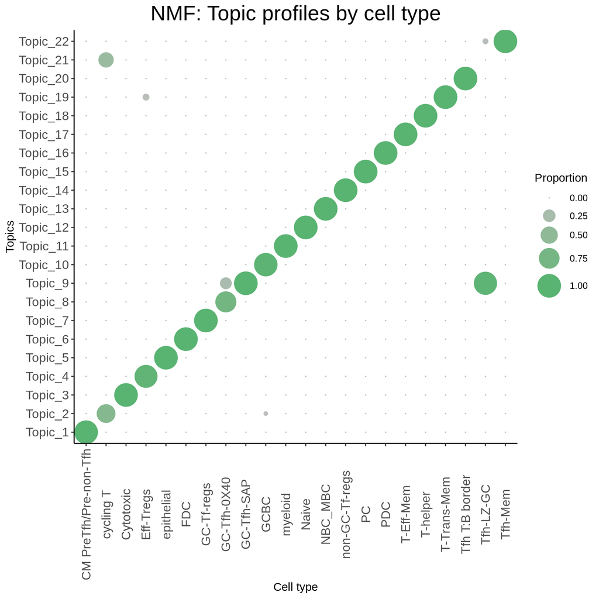

```r
nmf_mod_ls <- spotlight_ls[[1]]
nmf_mod <- nmf_mod_ls[[1]]

h <- NMF::coef(nmf_mod)
rownames(h) <- paste("Topic", 1:nrow(h), sep = "_")
topic_profile_plts <- SPOTlight::dot_plot_profiles_fun(
  h = h,
  train_cell_clust = nmf_mod_ls[[2]])

topic_profile_plts[[2]] +
  ggplot2::theme(axis.text.x = ggplot2::element_text(angle = 90),
                 axis.text = ggplot2::element_text(size = 12))
```

## Visualize deconvolution results

```r
decon_mtrx <- spotlight_ls[[2]]
decon_mtrx <- decon_mtrx[, colnames(decon_mtrx) != "res_ss"]

# Set as 0 cell types predicted to be under 1 % of the spot
# decon_mtrx[decon_mtrx < 0.03] <- 0
```

Change column names

```r
nm_df <- data.frame(
  mod_nm = stringr::str_replace_all(string = unique(all_markers$cluster),
                                    pattern = "[[:punct:]]|\\s|\\+" ,
                                    replacement = "."),
  plt_nm = unique(all_markers$cluster)
  )

# Save nm_df
"{cd4}/{robj_dir}/cd4_nm_df.rds" %>%
  glue::glue() %>%
  here::here() %>%
  saveRDS(
    object = nm_df,
    file = .)


new_cn <- data.frame(mod_nm = colnames(decon_mtrx)) %>%
  dplyr::left_join(nm_df, by = "mod_nm") %>%
  # Central.Mem.PASK. fives some trouble because it only changes between + an -
  # negative goes first and distinct solves it automatically
  dplyr::distinct() %>%
  dplyr::pull(plt_nm)

colnames(decon_mtrx) <- new_cn
```

We are going to add the deconvolution to the Seurat object.

```r
metadata <- cbind(sp_obj@meta.data, decon_mtrx)
sp_obj@meta.data <- metadata
```

Look at cells topic profile

```r
basis_spotlight <- data.frame(NMF::basis(spotlight_ls[[1]][[1]]))

train_labs <- spotlight_ls[[1]][[2]]
colnames(basis_spotlight) <- unique(stringr::str_wrap(train_labs, width = 30))

basis_spotlight[basis_spotlight < 0.0000001] <- 0

DT::datatable(basis_spotlight, filter = "top")
```

|  | CM PreTfh/Pre-non-Tfh | cycling T | Cytotoxic | Eff-Tregs | epithelial | FDC | GC-Tf-regs | GC-Tfh-0X40 | GC-Tfh-SAP | GCBC | myeloid | Naive | NBC_MBC | non-GC-Tf-regs | PC | PDC | T-Eff-Mem | T-helper | T-Trans-Mem | Tfh T:B border | Tfh-LZ-GC | Tfh-Mem |
| --- | --- | --- | --- | --- | --- | --- | --- | --- | --- | --- | --- | --- | --- | --- | --- | --- | --- | --- | --- | --- | --- | --- |
| IGKC | 0 | 0 | 0 | 0 | 0 | 0 | 0 | 0 | 0 | 0 | 0 | 0 | 0 | 0 | 0.00291254344963092 | 0 | 0 | 0 | 0 | 0 | 0 | 0 |
| IGHG1 | 0 | 0 | 0 | 0 | 0 | 0 | 0 | 0 | 0 | 0 | 0 | 0 | 0 | 0 | 0.00289408750923585 | 0 | 0 | 0 | 0 | 0 | 0 | 0 |
| IGHG3 | 0 | 0 | 0 | 0 | 0 | 0 | 0 | 0 | 0 | 0 | 0 | 0 | 0 | 0 | 0.00300901371117816 | 0 | 0 | 0 | 0 | 0 | 0 | 0 |
| IGLC2 | 0 | 0 | 0 | 0 | 0 | 0 | 0 | 0 | 0 | 0 | 0 | 0 | 0 | 0 | 0.00224427133037722 | 0 | 0 | 0 | 0 | 0 | 0 | 0 |
| IGHGP | 0 | 0 | 0 | 0 | 0 | 0 | 0 | 0 | 0 | 0 | 0 | 0 | 0 | 0 | 0.00227868029926451 | 0 | 0 | 0 | 0 | 0 | 0 | 0 |
| JCHAIN | 0 | 0 | 0 | 0 | 0 | 0 | 0 | 0 | 0 | 0 | 0 | 0 | 0 | 0 | 0.00330172420595794 | 5.99090926302673e-05 | 0 | 0 | 0 | 0 | 0 | 0 |
| S100A9 | 0 | 0 | 0 | 0 | 0.0031690854095579 | 0 | 0 | 0 | 0 | 0 | 0.000116192160965587 | 0 | 0 | 0 | 0 | 0 | 0 | 0 | 0 | 0 | 0 | 0 |
| FDCSP | 0 | 0 | 0 | 0 | 0.000291530442892307 | 0.00301994598290313 | 0 | 0 | 0 | 0 | 0 | 0 | 0 | 0 | 0 | 0 | 0 | 0 | 0 | 0 | 0 | 0 |
| LYZ | 0 | 0 | 0 | 0 | 0.00147558712146599 | 0 | 0 | 0 | 0 | 0 | 0.00171672184981309 | 0 | 0 | 0 | 0 | 0 | 0 | 0 | 0 | 0 | 0 | 0 |
| S100A8 | 0 | 0 | 0 | 0 | 0.00334775987208834 | 0 | 0 | 0 | 0 | 0 | 0.000166406002268062 | 0 | 0 | 0 | 0 | 0 | 0 | 0 | 0 | 0 | 0 | 0 |

[output cut: 3605 more lines]